# DATA605 Final: Kaggle Submission

Andrew Bowen

2023-04-30

### Load our Datasets

I uploaded the kaggle datasets to my GitHub, reading them here for reproducability.

```r
test_url <- "https://raw.githubusercontent.com/andrewbowen19/computationalMath605/main/data/test.csv"
train_url <- "https://raw.githubusercontent.com/andrewbowen19/computationalMath605/main/data/train.csv"

test <- read.csv(test_url)
train <- read.csv(train_url)
```

## Descriptive and Inferential Statistics

```r
summary(train)
```

```
##        Id           MSSubClass      MSZoning          LotFrontage
##  Min.   :   1.0   Min.   : 20.0   Length:1460        Min.   : 21.00
##  1st Qu.: 365.8   1st Qu.: 20.0   Class :character   1st Qu.: 59.00
##  Median : 730.5   Median : 50.0   Mode  :character   Median : 69.00
##  Mean   : 730.5   Mean   : 56.9                      Mean   : 70.05
##  3rd Qu.:1095.2   3rd Qu.: 70.0                      3rd Qu.: 80.00
##  Max.   :1460.0   Max.   :190.0                      Max.   :313.00
##                                                      NA's   :259
##     LotArea          Street             Alley             LotShape
##  Min.   :  1300   Length:1460        Length:1460        Length:1460
##  1st Qu.:  7554   Class :character   Class :character   Class :character
##  Median :  9478   Mode  :character   Mode  :character   Mode  :character
##  Mean   : 10517
##  3rd Qu.: 11602
##  Max.   :215245
##
##  LandContour         Utilities          LotConfig          LandSlope
##  Length:1460        Length:1460        Length:1460        Length:1460
##  Class :character   Class :character   Class :character   Class :character
##  Mode  :character   Mode  :character   Mode  :character   Mode  :character
##
##
##
##
##  Neighborhood        Condition1         Condition2          BldgType
##  Length:1460        Length:1460        Length:1460        Length:1460
##  Class :character   Class :character   Class :character   Class :character
##  Mode  :character   Mode  :character   Mode  :character   Mode  :character
##
##
##
##
##   HouseStyle         OverallQual      OverallCond      YearBuilt
##  Length:1460        Min.   : 1.000   Min.   :1.000   Min.   :1872
##  Class :character   1st Qu.: 5.000   1st Qu.:5.000   1st Qu.:1954
##  Mode  :character   Median : 6.000   Median :5.000   Median :1973
##                     Mean   : 6.099   Mean   :5.575   Mean   :1971
##                     3rd Qu.: 7.000   3rd Qu.:6.000   3rd Qu.:2000
##                     Max.   :10.000   Max.   :9.000   Max.   :2010
##
```

[output cut: 113 more lines]

```
##  Min.   : 1.000   Min.   :2006   Length:1460        Length:1460
##  1st Qu.: 5.000   1st Qu.:2007   Class :character   Class :character
##  Median : 6.000   Median :2008   Mode  :character   Mode  :character
##  Mean   : 6.322   Mean   :2008
##  3rd Qu.: 8.000   3rd Qu.:2009
##  Max.   :12.000   Max.   :2010
##
##    SalePrice
##  Min.   : 34900
##  1st Qu.:129975
##  Median :163000
##  Mean   :180921
##  3rd Qu.:214000
##  Max.   :755000
##
```

Creating a scatter plot of the basement square footage and sale price ($)

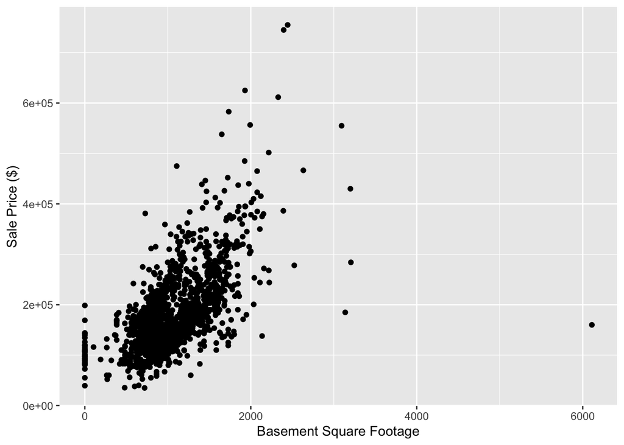

```r
ggplot(train, aes(x=TotalBsmtSF, y=SalePrice)) + geom_point() + xlab("Basement Square Footage") + ylab("Sale Price ($)")
```

Creating another scatter plot between the lot area ($ft^2$) and `SalePrice`

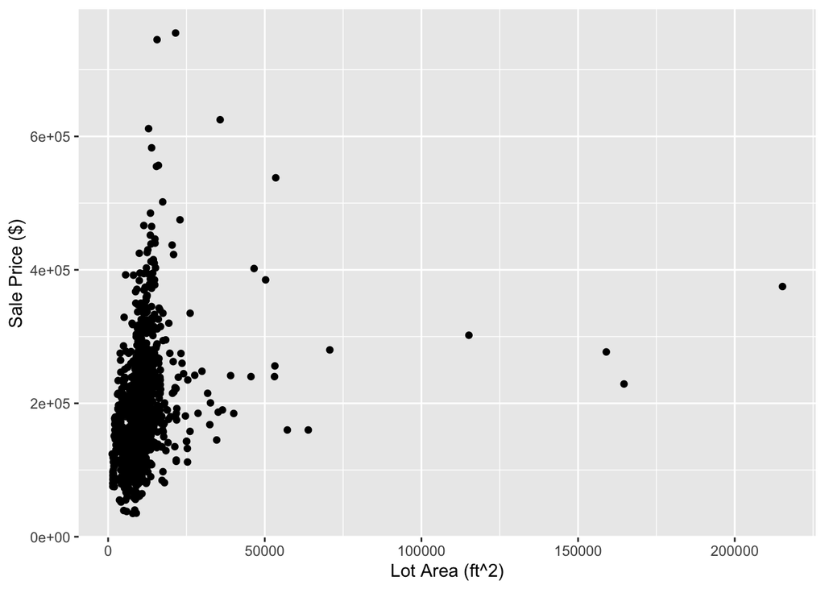

```r
ggplot(train, aes(x=LotArea, y=SalePrice)) + geom_point() + xlab("Lot Area (ft^2)") + ylab("Sale Price ($)")
```

Generating a correlation matrix between our three quantitative variables above (`LotArea`, `TotalBsmtSF`, `SalePrice`)

```r
(corTrain <- cor(train[,c("LotArea", "TotalBsmtSF", "SalePrice") ]))
```

```
##               LotArea TotalBsmtSF SalePrice
## LotArea     1.0000000   0.2608331 0.2638434
## TotalBsmtSF 0.2608331   1.0000000 0.6135806
## SalePrice   0.2638434   0.6135806 1.0000000
```

Running `cor.test` for each permutation of quantitative variables above

```r
for (i in colnames(corTrain)){
  for (j in colnames(corTrain)){
    if (i != j){
      ctest <- cor.test(corTrain[,c(i)], corTrain[,c(j)], conf.level=0.8)
      print(ctest)
    }
  }
}
```

```
##
##  Pearson's product-moment correlation
##
## data:  corTrain[, c(i)] and corTrain[, c(j)]
## t = -1.6444, df = 1, p-value = 0.3478
## alternative hypothesis: true correlation is not equal to 0
## sample estimates:
##        cor
## -0.8544218
##
##
##  Pearson's product-moment correlation
##
## data:  corTrain[, c(i)] and corTrain[, c(j)]
## t = -1.6097, df = 1, p-value = 0.3539
## alternative hypothesis: true correlation is not equal to 0
## sample estimates:
##        cor
## -0.8494291
##
##
##  Pearson's product-moment correlation
##
## data:  corTrain[, c(i)] and corTrain[, c(j)]
## t = -1.6444, df = 1, p-value = 0.3478
## alternative hypothesis: true correlation is not equal to 0
## sample estimates:
##        cor
## -0.8544218
##
##
##  Pearson's product-moment correlation
##
## data:  corTrain[, c(i)] and corTrain[, c(j)]
## t = 0.50613, df = 1, p-value = 0.7017
## alternative hypothesis: true correlation is not equal to 0
## sample estimates:
##       cor
## 0.4515869
##
##
##  Pearson's product-moment correlation
##
## data:  corTrain[, c(i)] and corTrain[, c(j)]
## t = -1.6097, df = 1, p-value = 0.3539
## alternative hypothesis: true correlation is not equal to 0
## sample estimates:
##        cor
## -0.8494291
##
##
##  Pearson's product-moment correlation
##
## data:  corTrain[, c(i)] and corTrain[, c(j)]
## t = 0.50613, df = 1, p-value = 0.7017
## alternative hypothesis: true correlation is not equal to 0
## sample estimates:
##       cor
## 0.4515869
```

For each combination of variables tested, we have p-values greater than our significance level ($\alpha = 0.2$). This indicates that we can not reject our null hypothesis that the true population correlation between variables is equal to 0.

### Linear Algebra and Correlation

```r
det(corTrain)
```

```
## [1] 0.5703238
```

Our determinant is **not** equal to 0, so we should be able to invert our correlation matrix. We can do this using the built-in `solve` function in R:

```r
(invCor <- solve(corTrain))
```

```
##                LotArea TotalBsmtSF  SalePrice
## LotArea      1.0932718  -0.1734874 -0.1820040
## TotalBsmtSF -0.1734874   1.6313307 -0.9551793
## SalePrice   -0.1820040  -0.9551793  1.6341000
```

```r
corTrain %*% invCor
```

```
##                   LotArea TotalBsmtSF    SalePrice
## LotArea      1.000000e+00           0 0.000000e+00
## TotalBsmtSF  0.000000e+00           1 2.220446e-16
## SalePrice   -2.775558e-17           0 1.000000e+00
```

Accounting for some floating point errors, the above matrix product is the identity matrix, which holds for the multiplication of a matrix $A$ with its inverse $A^{-1}$: $I = AA^{-1}$

LU Decomposition of our correlation matrix from above using the `matrixcalc` package

```r
(LU <- lu.decomposition(corTrain))
```

```
## $L
##           [,1]      [,2] [,3]
## [1,] 1.0000000 0.0000000    0
## [2,] 0.2608331 1.0000000    0
## [3,] 0.2638434 0.5845293    1
##
## $U
##      [,1]      [,2]      [,3]
## [1,]    1 0.2608331 0.2638434
## [2,]    0 0.9319661 0.5447615
## [3,]    0 0.0000000 0.6119577
```

Let’s verify that our LU decomposition does in fact equal our original correlation matrix when multiplied together: $A = LU$

```r
A <- LU$L %*% LU$U
A == corTrain
```

```
##             LotArea TotalBsmtSF SalePrice
## LotArea        TRUE        TRUE      TRUE
## TotalBsmtSF    TRUE        TRUE      TRUE
## SalePrice      TRUE        TRUE      TRUE
```

### Calculus-Bases Probability & Statistics

Let’s use the `MasVnrArea` variable, which is definitely skew-right. We’ll need to remove a few `NA` values from our data first

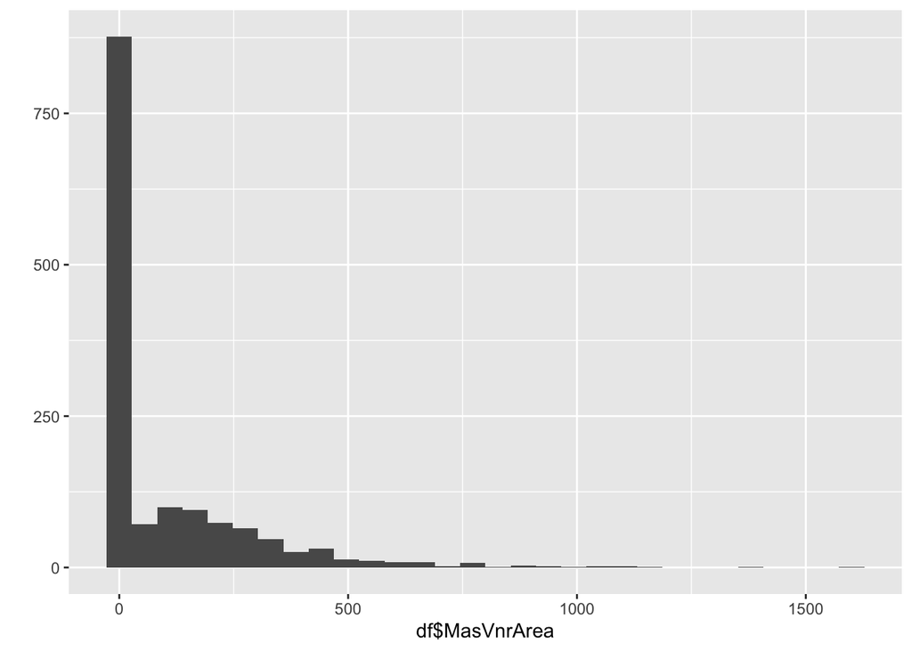

```r
df <- train %>% filter(!is.na(MasVnrArea))
qplot(df$MasVnrArea)
```

Calling `fitdistr` from the `MASS` package to fit our dataset variable to an exponential

```r
# Fit our distribution to an exponential
fit <- fitdistr(df$MasVnrArea, "exponential")

# Getting the rate poarameter lambda
lambda <- fit$estimate[["rate"]]
```

Now let’s generate random values with our `lambda` variable as the rate parameter

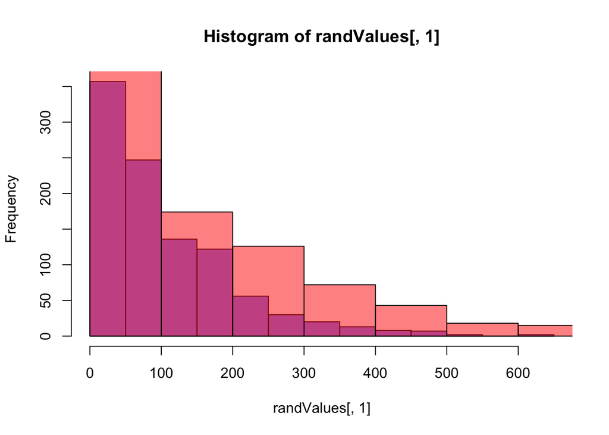

```r
dat <- rexp(1000, lambda)
randValues <- as.data.frame(dat, col.names=character(1))


hist(randValues[,1], col=rgb(0,0,1,0.5))
hist(df$MasVnrArea, add=TRUE, col=rgb(1,0,0,0.5))
```

These both look to be skew-right with similar shapes (although the Kaggle data has a bit longer tail). Overall, these historgrams are similarly shaped and likely would have been pulled from the same distribution

```r
p5 <- pexp(0.05, rate=lambda)
p95 <- pexp(0.95, rate=lambda)
```

Let’s now [construct a 95% confidence interval](https://www.r-bloggers.com/2021/11/calculate-confidence-intervals-in-r/) from our Kaggle variable `MasVnrArea`. To do this we’ll need our sample mean and standard deviation for this field

```r
n <- length(df$MasVnrArea)
mu <- mean(df$MasVnrArea)
sigma <- sd(df$MasVnrArea)

margin <- qt(0.975,df=n-1)*sigma/sqrt(n)

lower_interval <- mu - margin
upper_interval <- mu + margin
print(lower_interval)
```

```
## [1] 94.36422
```

```r
print(upper_interval)
```

```
## [1] 113.0063
```

Getting 5th and 95th percentile of our `MasVnrArea` variable

```r
quantile(df$MasVnrArea, c(0.05, 0.95))
```

```
##  5% 95%
##   0 456
```

### Modeling

```r
mylm <- lm(SalePrice ~ FullBath + LotArea + OverallCond + GarageArea, train)

summary(mylm)
```

```
##
## Call:
## lm(formula = SalePrice ~ FullBath + LotArea + OverallCond + GarageArea,
##     data = train)
##
## Residuals:
##     Min      1Q  Median      3Q     Max
## -259833  -29066   -4312   20005  426711
##
## Coefficients:
##               Estimate Std. Error t value Pr(>|t|)
## (Intercept) -2.008e+04  9.529e+03  -2.107 0.035314 *
## FullBath     5.336e+04  2.890e+03  18.462  < 2e-16 ***
## LotArea      1.073e+00  1.467e-01   7.315 4.23e-13 ***
## OverallCond  4.587e+03  1.321e+03   3.472 0.000532 ***
## GarageArea   1.704e+02  7.455e+00  22.863  < 2e-16 ***
## ---
## Signif. codes:  0 '***' 0.001 '**' 0.01 '*' 0.05 '.' 0.1 ' ' 1
##
## Residual standard error: 54880 on 1455 degrees of freedom
## Multiple R-squared:  0.524,  Adjusted R-squared:  0.5227
## F-statistic: 400.5 on 4 and 1455 DF,  p-value: < 2.2e-16
```

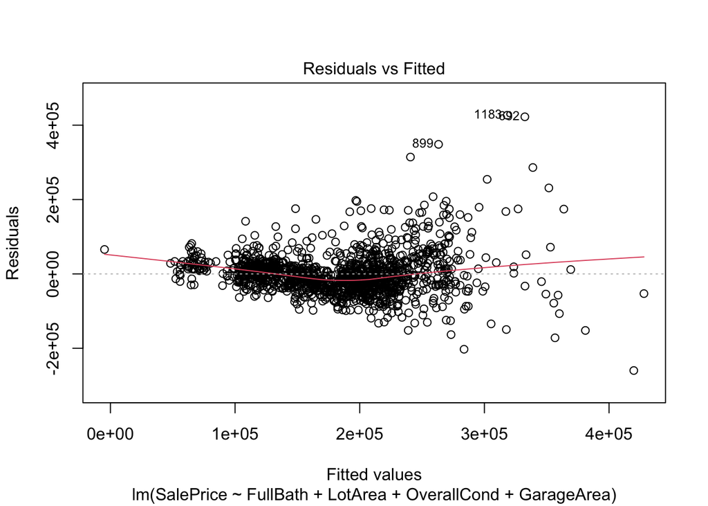

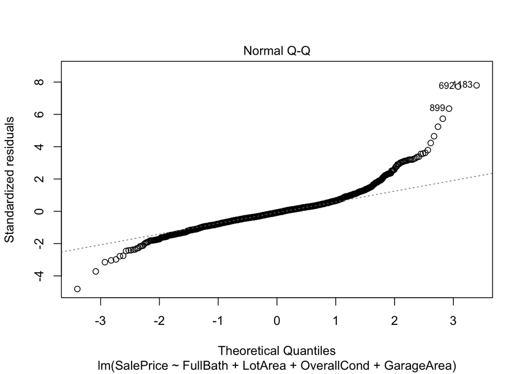

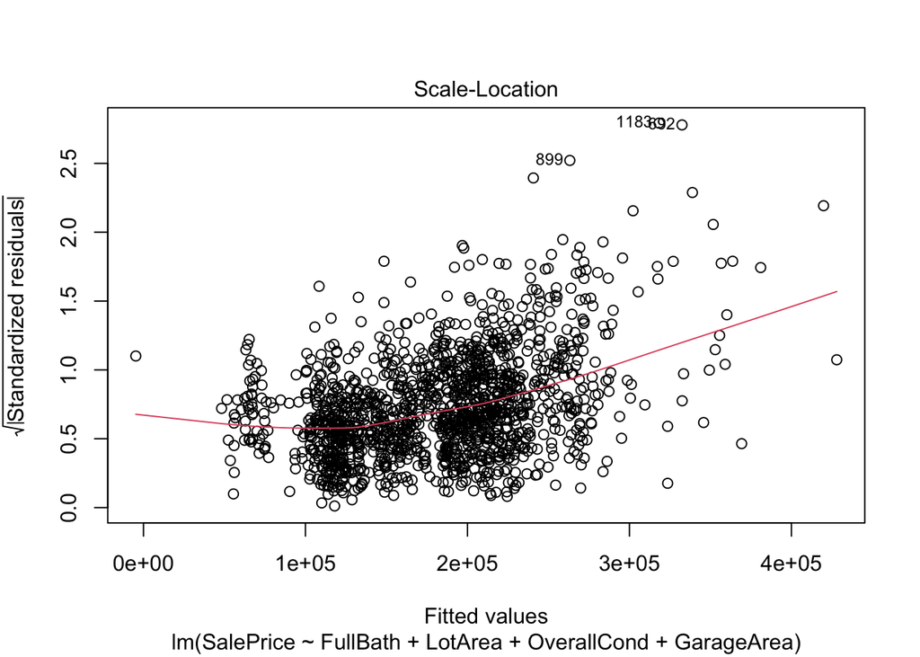

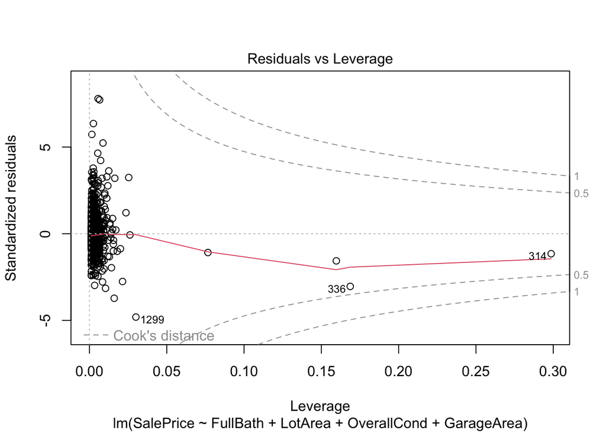

```r
plot(mylm)
```

#### Linear Regression Assumptions

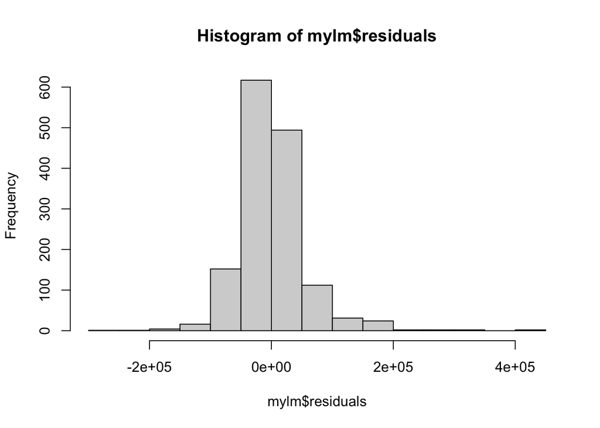

```r
hist(mylm$residuals)
```

```r
shapiro.test(mylm$residuals)
```

```
##
##  Shapiro-Wilk normality test
##
## data:  mylm$residuals
## W = 0.89165, p-value < 2.2e-16
```

3. Homoscedasticity We can test this with a [Breush-Pagan test](http://math.furman.edu/~dcs/courses/math47/R/library/lmtest/html/bptest.html) in R

```r
bptest(mylm)
```

```
##
##  studentized Breusch-Pagan test
##
## data:  mylm
## BP = 140, df = 4, p-value < 2.2e-16
```

### Results

```r
test$SalePrice = predict(mylm, newdata = test)
```

Now we can write our predicted values to a csv file for Kaggle submission

```r
# Get DF of only Id and price column for submission
df <- as.data.frame(test[, c("Id", "SalePrice")])

# impute any missing values for Kaggle as the mean sale price
x <- mean(df$SalePrice, na.rm=TRUE)
df[is.na(df$SalePrice), "SalePrice"] <- x

# Write data to csv
write.csv(df, "submission.csv", row.names=F)
```